# Homework 6

Devin Warner

2022-04-11

In this homework you will practice using cross-validation to fit data using LASSO and K-nearest neighbor models. Please upload to your GitHub an R Markdown document answering the following:

## Question 1 (20 points)

A researcher wants to determine how employee salaries at a certain company are related to the length of employment, previous experience, and education. The researcher selects eight employees from the company and obtains the data shown below (the dataset is available as a tibble in the .Rmd).

```
## # A tibble: 8 × 4
##   Salary Employment Experience Education
##    <dbl>      <dbl>      <dbl>     <dbl>
## 1  57310         10          2        16
## 2  57380          5          6        16
## 3  54135          3          1        12
## 4  56985          6          5        14
## 5  58715          8          8        16
## 6  60620         20          0        12
## 7  59200          8          4        18
## 8  60320         14          6        17
```

1. Fit a standard least squares regression model to these data and interpret the results. After looking at the statistical significance of the $\beta$s, which covariates would you include in a final model?

```r
  lm_model <- lm(Salary~.,data = salary)
  summary(lm_model)
```

```
##
## Call:
## lm(formula = Salary ~ ., data = salary)
##
## Residuals:
##       1       2       3       4       5       6       7       8
## -824.76  156.82 -153.52  158.90  -56.65  364.09  804.95 -449.82
##
## Coefficients:
##             Estimate Std. Error t value Pr(>|t|)
## (Intercept) 49764.45    1981.35  25.116 1.49e-05 ***
## Employment    364.41      48.32   7.542  0.00166 **
## Experience    227.62     123.84   1.838  0.13991
## Education     266.94     147.36   1.812  0.14430
## ---
## Signif. codes:  0 '***' 0.001 '**' 0.01 '*' 0.05 '.' 0.1 ' ' 1
##
## Residual standard error: 659.5 on 4 degrees of freedom
## Multiple R-squared:  0.9438, Adjusted R-squared:  0.9017
## F-statistic:  22.4 on 3 and 4 DF,  p-value: 0.005804
```

The standard least squares regression line using Employment, Experience and Education explains about 94% of the variation in salary. Of these variables, Employment is significant at the $\alpha$=0.01 level, while the other two variables are not significant at the $\alpha$=0.10 level. Based off of the statistical significance of the $\beta$s only, I would chose only Employment to include in a final model.

2. Use to fit a LASSO model to these covariates. Try $\lambda$=1000, 800, 500, and 1. How do the results compare to each other and the least squares model?

```r
lasso_salary_1000 <- glmnet(as.matrix(salary[,-1]), salary$Salary, lambda = 1000,
                            family = "gaussian", alpha = 1)
lasso_salary_1000$beta
```

```
## 3 x 1 sparse Matrix of class "dgCMatrix"
##                  s0
## Employment 121.3593
## Experience   .
## Education    .
```

```r
lasso_salary_800 <- glmnet(as.matrix(salary[,-1]), salary$Salary, lambda = 800,
                           family = "gaussian", alpha = 1)
lasso_salary_800$beta
```

```
## 3 x 1 sparse Matrix of class "dgCMatrix"
##                  s0
## Employment 160.9970
## Experience   .
## Education   12.5724
```

```r
lasso_salary_500 <- glmnet(as.matrix(salary[,-1]), salary$Salary, lambda = 500,
                           family = "gaussian", alpha = 1)
lasso_salary_500$beta
```

```
## 3 x 1 sparse Matrix of class "dgCMatrix"
##                  s0
## Employment 226.7347
## Experience   .
## Education  173.6925
```

```r
lasso_salary_1 <- glmnet(as.matrix(salary[,-1]), salary$Salary, lambda = 1,
                         family = "gaussian", alpha = 1)
lasso_salary_1$beta
```

```
## 3 x 1 sparse Matrix of class "dgCMatrix"
##                  s0
## Employment 364.1504
## Experience 227.2122
## Education  266.7132
```

We see that the LASSO model with $\lambda = 1$ has model coefficients that equivalent to the standard least squares regression line. As lambda increases, the coefficients on Experience and Education decrease until they are equivalent to 0 in the model. The coefficient on Experience goes to 0 first, and the Education. This agrees with my choice in part (a) to only include Employment in the final model.

3. Which LASSO model (i.e. $\lambda$) would you select? (note you are not just restricted to $\lambda$ values of 1000, 800, 500, and 1). Justify your answer.

We want to select the $\lambda$ value that produces the best accuracy for prediction. Using cross validation we can find the optimal $\lambda$ value.

```r
lasso.cv <- cv.glmnet(as.matrix(salary[,-1]), salary$Salary, alpha = 1)
```

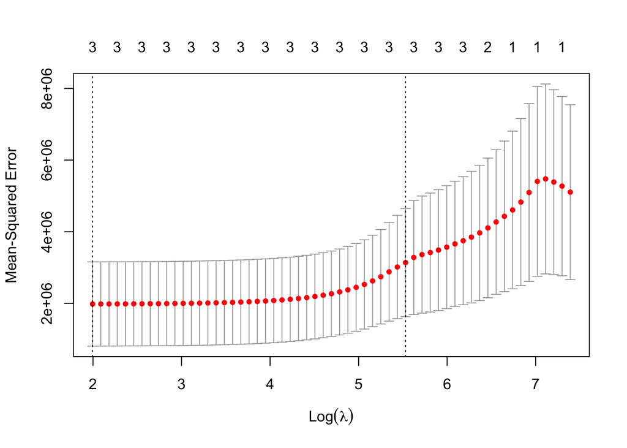

```r
plot(lasso.cv)
```

```r
(lasso.lambda <- lasso.cv$lambda.min)
```

```
## [1] 7.351223
```

As shown above, the best $\lambda$ value for prediction is 7.351223.

4. Use to fit a Ridge regression model to these data. Try $\lambda$=1000, 800, 500, and 1. How do these results differ from the least squares and LASSO models?

```r
ridge_salary_1000 <- glmnet(as.matrix(salary[,-1]), salary$Salary, lambda = 1000,
                            family = "gaussian", alpha = 0)
ridge_salary_1000$beta
```

```
## 3 x 1 sparse Matrix of class "dgCMatrix"
##                  s0
## Employment 228.1970
## Experience 114.1154
## Education  213.4515
```

```r
ridge_salary_800 <- glmnet(as.matrix(salary[,-1]), salary$Salary, lambda = 800,
                           family = "gaussian", alpha = 0)
ridge_salary_800$beta
```

```
## 3 x 1 sparse Matrix of class "dgCMatrix"
##                  s0
## Employment 246.3775
## Experience 125.7664
## Education  225.6544
```

```r
ridge_salary_500 <- glmnet(as.matrix(salary[,-1]), salary$Salary, lambda = 500,
                           family = "gaussian", alpha = 0)
ridge_salary_500$beta
```

```
## 3 x 1 sparse Matrix of class "dgCMatrix"
##                  s0
## Employment 279.9839
## Experience 149.4110
## Education  245.0589
```

```r
ridge_salary_1 <- glmnet(as.matrix(salary[,-1]), salary$Salary, lambda = 1,
                         family = "gaussian", alpha = 0)
ridge_salary_1$beta
```

```
## 3 x 1 sparse Matrix of class "dgCMatrix"
##                  s0
## Employment 364.2004
## Experience 227.4089
## Education  266.9118
```

Again, a Ridge model with $\lambda = 1$ is equivalent to the standard least square regression line. We see in the Ridge model though that variable coefficients do not decrease to 0 as $\lambda$ increases. However, they still decrease, with the coefficient on Experience decreasing first and by a larger magnitude than Education decreases.

## Question 2 (20 points)

The dataset provides nutritional information on nearly 80 common breakfast cereals. The ‘rating’ column provides an overall rating for each cereal (possibly from Consumer Reports?). Use a LASSO regression model to identify the best predictors of cereal rating. Evaluate the model for $\lambda$ values of 8, 5, 3, and 1 (among others). Which $\lambda$ would you choose and why? Which covariates best explain the rating?

We will use a cross validation to determine the best value of $\lambda$ for our data. First, we will split our data into training and testing data. (For reproducibility’s sake, we will set the seed to 8561)

```r
set.seed(8561)

test_ind <- sample(nrow(cereal), 0.3*nrow(cereal))
cereal_test <- cereal[test_ind,]
cereal_train <- cereal[-test_ind,]
```

Next, we will train a cross validation LASSO regression model using our training data. We will exclude the *name* covariate from our modeling as it is an identifying factor. Output below is the change in change in MSE as $\lambda$ increases, as well as the $\lambda$ value that gives the lowest (best) MSE.

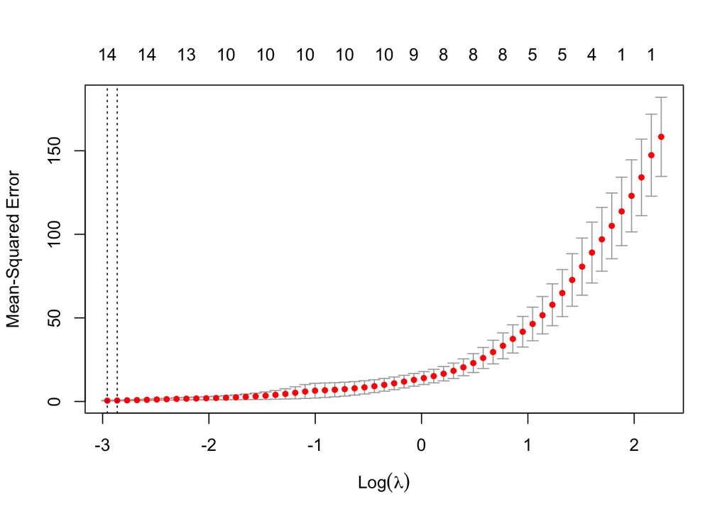

```r
cereal_lasso <- cv.glmnet(as.matrix(cereal_train[,-c(1,14)]), cereal_train$rating, alpha = 1, lamdba = seq(1,10))
plot(cereal_lasso)
```

```r
(cereal.lambda <- cereal_lasso$lambda.min)
```

```
## [1] 0.05204486
```

Now, we will output the coefficients of the LASSO model with our best $\lambda$ value, as well as the MSE for the training data.

```
## 22 x 1 sparse Matrix of class "dgCMatrix"
##                      s1
## (Intercept) 55.58092325
## calories    -0.21279658
## protein      3.05088411
## fat         -1.74991769
## sodium      -0.05165748
## fiber        2.84053721
## carbo        0.99528516
## sugars      -0.80216895
## potass      -0.01690655
## vitamins    -0.04548866
## shelf        .
## weight       .
## cups        -0.08759551
## mfrA        -0.21189646
## mfrG        -0.30535372
## mfrK         .
## mfrN         0.93131788
## mfrP         .
## mfrQ        -0.09076739
## mfrR         .
## typeCold     .
## typeHot      .
```

```
## [1] "The training MSE with λ = 0.05 is: 0.148165"
```

The variables (covariates) that have non-zero coefficients are the best for explaining rating. Since the coefficients are penalized, the larger the coefficient is, the better it is at explaining rating. We see that the covariates *fiber* and *protein* have the greatest positive affect on rating, and *fat* and *sugars* have the greatest negative affect on rating.

It is important to note that the *mfr* variables that were excluded from the model appeared very sparsely in the data set (less than 10 observations). The same happens with the *type* variable as there are only 3 *H* observations. This could potentially be a problem because none of these observations may have ended up in the training data because they were so sparse.

Now, we will see how our LASSO model with the best $\lambda$ value does at predicting unseen data. This model has 14 covariates. For reference, we will calculate a baseline accuracy of the test data set using the mean of *rating* as the estimate for all observations.

```r
baseline <- mean((mean(cereal_test$rating)-cereal_test$rating)^2)

cereal_preds <- predict(cereal_lasso, s = cereal.lambda, newx = as.matrix(cereal_test[,-c(1,14)]))
mse <- mean((cereal_preds - cereal_test$rating)^2)
```

```
## [1] "The baseline MSE is: 279.602039814125"
```

```
## [1] "The LASSO model with λ = 0.05  MSE is: 0.567441"
```

## Question 3 (20 points)

An automobile consulting company wants to understand the factors on which the pricing of cars depends. Use an Elastic Net model and the dataset to determine which variables are significant in predicting the price of a car. Use cross-validation to find an optimal value for $\lambda$. Interpret your final model.

Let us perform some exploratory data analysis to see what kind of information our data contains. First we will examine the distribution of levels inside our factor varialbes, *fuel*, *transmission*,*seller_type*, and *owner*.

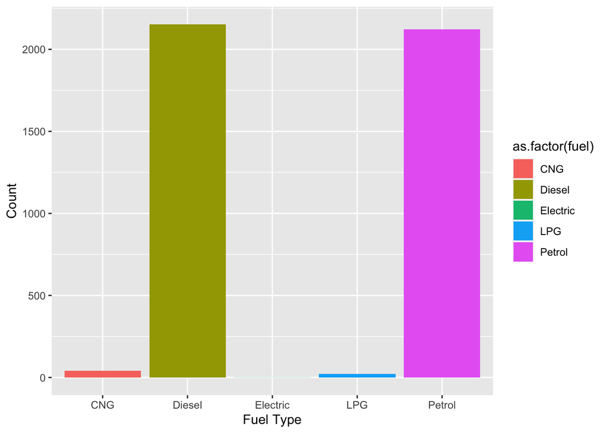

```r
carprice %>%
  ggplot(aes(x = fuel, fill = as.factor(fuel))) +
  geom_bar() +
  xlab("Fuel Type") +
  ylab("Count")
```

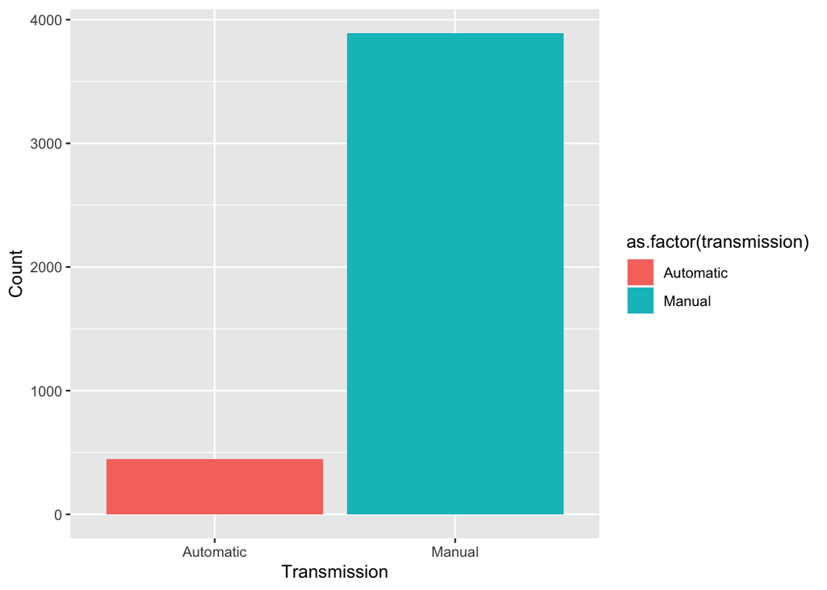

```r
carprice %>%
  ggplot(aes(x = transmission, fill = as.factor(transmission))) +
  geom_bar() +
  xlab("Transmission") +
  ylab("Count")
```

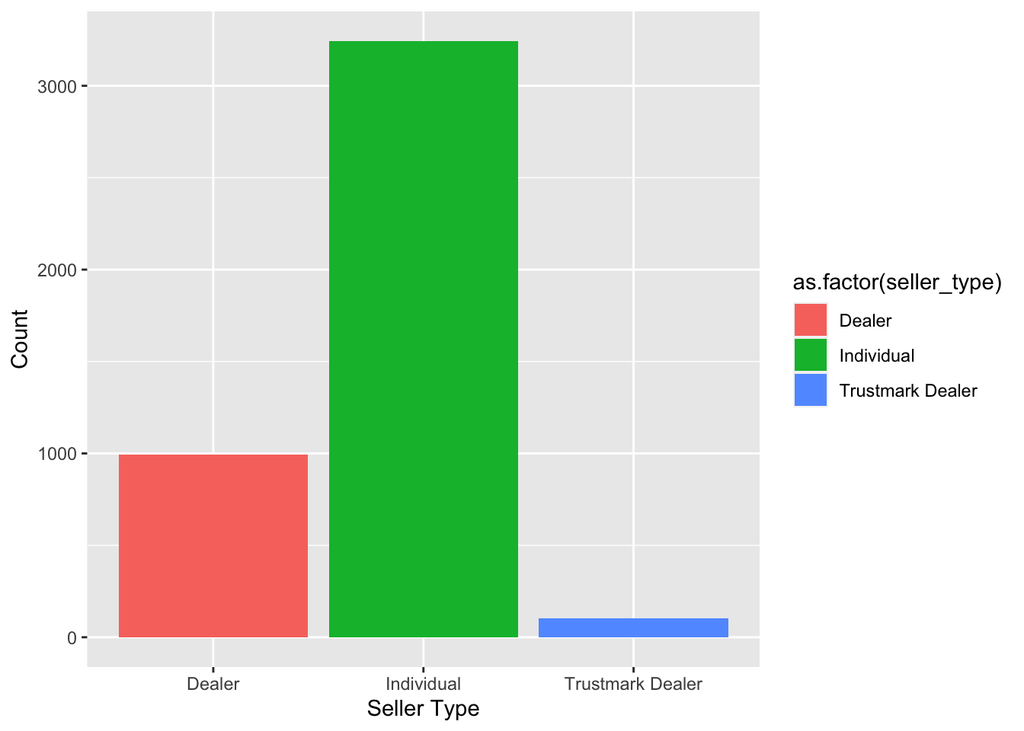

```r
carprice %>%
  ggplot(aes(x = seller_type, fill = as.factor(seller_type))) +
  geom_bar() +
  xlab("Seller Type") +
  ylab("Count")
```

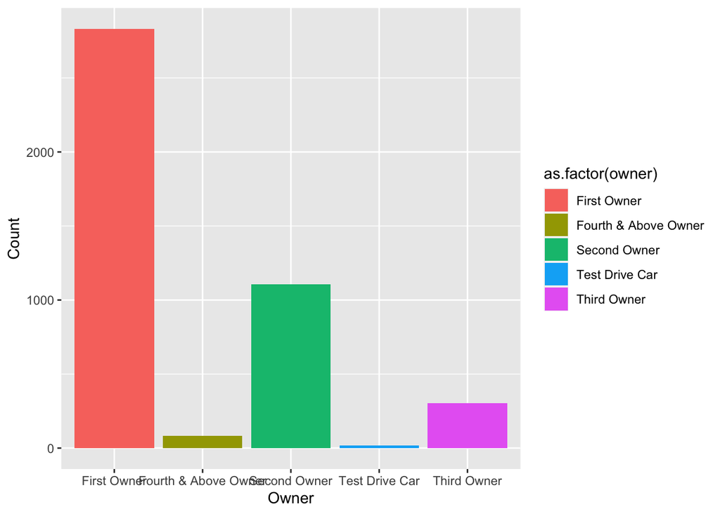

```r
carprice %>%
  ggplot(aes(x = owner, fill = as.factor(owner))) +
  geom_bar() +
  xlab("Owner") +
  ylab("Count")
```

From these plots we see that most of our observations use Diesel or Petrol fuel, are manual transmission, sold by individuals, and are currently owned by the first owner. We will convert each of these factor variables into dummy variables

Next, we will see view how our continuous variables (*year* and *km_driven*) are correlated to our *y* variable, *selling_price*.

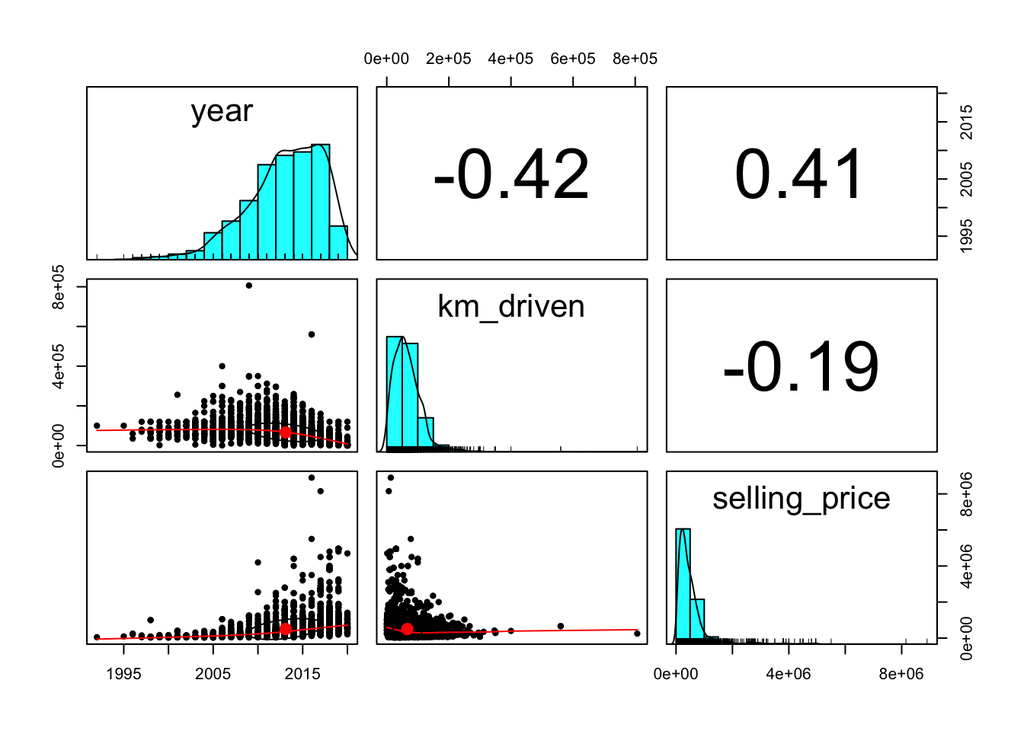

```r
pairs.panels(carprice[,c(2,4,3)])
```

We see from the plot above that *year* appears to have a positive, exponential effect on *selling_price* (bottom left plot), and *km_driven* has a negative, exponential effect on *selling_price* (bottom middle plot). The lines in red are a lowess smoother, not an exponential line.

Now, we move forward to creating our Elastic Net model. I have chosen to stay with a LASSO regression since I like the feature of coefficients reducing to zero. First, we will split our data into training and testing data. For reproducibility, we will use a seed of 8561.

```r
# Split Data
set.seed(8561)
test_ind <- sample(nrow(carprice), 0.3*nrow(carprice))
car_test <- carprice[test_ind,]
car_train <- carprice[-test_ind,]
```

We will now run a series of cross-validated LASSO regression models using our training data to predict *selling_price* using all other variables (except the identifying factor, *name*).

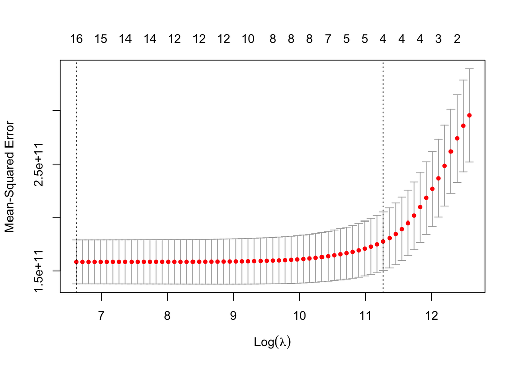

```r
# Run Model
car_lasso_cv <- cv.glmnet(as.matrix(car_train[,-c(1,3)]), car_train$selling_price, alpha = 1)

# Examine model
plot(car_lasso_cv)
```

```r
(car.lambda <- car_lasso_cv$lambda.min)
```

```
## [1] 747.1709
```

```r
# View coeff at different lambdas
X <- predict(car_lasso_cv,s=exp(10),type="coefficients")
tibble(Variable = names(X[,1]), Coefficient = X[,1]) %>% filter(Coefficient != 0)
```

```
## # A tibble: 9 × 2
##   Variable           Coefficient
##   <chr>                    <dbl>
## 1 (Intercept)           -6.96e+7
## 2 year                   3.47e+4
## 3 km_driven             -3.67e-1
## 4 fuelDiesel             2.34e+5
## 5 sellerIndividual      -4.73e+4
## 6 sellerTrustmark        4.13e+4
## 7 transmissionAuto       7.66e+5
## 8 transmissionManual    -5.99e-7
## 9 firstOwner             1.60e+4
```

We see from this table that *year*,*km_driven*,*fuelDiesel*,*sellerIndividual*,*sellerTrustmark*,*transmissionAuto*,*transmissionManual*, and *firstOwner* are the most important for prediction. This is an interesting result for the following reasons:

1. The dummy variable for Diesel is the only one that remains. By our EDA results, most observations were either Diesel or Petrol cars. This remaining variable acts like an indicator for a diesel car. If a car uses diesel fuel it is predicted to be more expensive then any other car (mostly petrol).
2. A similar thing happens with the dummy variables for *Owner*. Only the *firstOwner* variable remains and acts as an indicator for a first owner car or not. Our model is showing us in this data set that there is not a significant difference in the *selling_price* between second, third, and more than fourth owner cars.
3. I am surprised that both *transmission* dummy variables remain in the final model. Because the factor is binary, I was for sure that at least one fo them would disappear. The price difference in automatic and manual cars must be different enough that our model decided to keep both dummy variables.
4. The variables *year* and *km_driven* behave as we would expect from our EDA.

Now let us see how our model(s) does at predicting unseen data. We will be using Root Mean Squared Error as a measurement of accuracy. The table below shows baseline RMSE (predict all *selling_price* values as the mean of *selling_price*), and RMSE using LASSO models with $log(\lambda) = 6.7$ (picked by glmnet) and $log(\lambda) = 10$ (picked by us).

```r
# Check test accuracy
baseline_rmse <- sqrt(mean((mean(car_test$selling_price)-car_test$selling_price)^2))

car_preds_1 <- predict(car_lasso_cv, s = car.lambda, newx = as.matrix(car_test[,-c(1,3)]))
test_rmse_1 <- sqrt(mean((car_preds_1 - car_test$selling_price)^2))

car_preds_2 <- predict(car_lasso_cv, s = exp(10), newx = as.matrix(car_test[,-c(1,3)]))
test_rmse_2 <- sqrt(mean((car_preds_2 - car_test$selling_price)^2))

tibble(Model = c("Baseline", "LASSO (log(\u03BB) = 6.7)", "LASSO (log(\u03BB) = 10)"),
       Test_RMSE = c(baseline_rmse, test_rmse_1, test_rmse_2))
```

```
## # A tibble: 3 × 2
##   Model                Test_RMSE
##   <chr>                    <dbl>
## 1 Baseline               650282.
## 2 LASSO (log(λ) = 6.7)   490833.
## 3 LASSO (log(λ) = 10)    497259.
```

```r
sd(car_test$selling_price)
```

```
## [1] 650531.7
```

We see that our RMSE is smaller than the standard deviation, which is a good sign that we have strong predictive power.

Our model coefficients for our LASSO model are had to interpret because they are penalized. Let us run a standard least squares regression line using the variables picked by our LASSO model to get interpretable coefficients (we exclude *transmissionManual* because it is perfectly correlated with *transmissionAuto*).

```r
car_lm <- lm(selling_price~year+km_driven+fuelDiesel+sellerIndividual+sellerTrustmark+
               transmissionAuto+firstOwner,data = carprice)
summary(car_lm)
```

```
##
## Call:
## lm(formula = selling_price ~ year + km_driven + fuelDiesel +
##     sellerIndividual + sellerTrustmark + transmissionAuto + firstOwner,
##     data = carprice)
##
## Residuals:
##      Min       1Q   Median       3Q      Max
## -1185311  -167437   -24629   114779  7546916
##
## Coefficients:
##                    Estimate Std. Error t value Pr(>|t|)
## (Intercept)      -7.130e+07  3.795e+06 -18.788  < 2e-16 ***
## year              3.560e+04  1.886e+03  18.877  < 2e-16 ***
## km_driven        -9.699e-01  1.675e-01  -5.789 7.57e-09 ***
## fuelDiesel        2.897e+05  1.410e+04  20.542  < 2e-16 ***
## sellerIndividual -6.975e+04  1.630e+04  -4.278 1.93e-05 ***
## sellerTrustmark   1.643e+05  4.441e+04   3.699 0.000219 ***
## transmissionAuto  8.668e+05  2.195e+04  39.481  < 2e-16 ***
## firstOwner        3.426e+04  1.555e+04   2.204 0.027598 *
## ---
## Signif. codes:  0 '***' 0.001 '**' 0.01 '*' 0.05 '.' 0.1 ' ' 1
##
## Residual standard error: 426100 on 4332 degrees of freedom
## Multiple R-squared:  0.4584, Adjusted R-squared:  0.4575
## F-statistic: 523.8 on 7 and 4332 DF,  p-value: < 2.2e-16
```

We can now interpret each of these variables as an increase or decrease in *selling_price* for a one unit increase in each of the variables. For example, for every additional km driven on the car, the price of the car decreases by $0.97. Overall, these variables explain about 45% of the variation in *selling_price*.